# bastln mitochondrial genes against their contigs

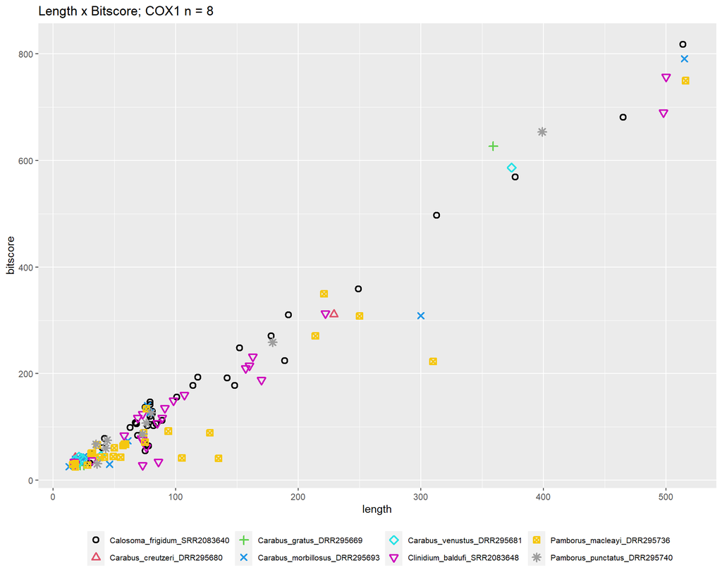

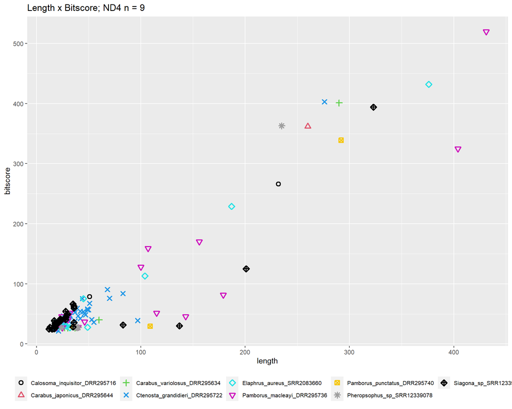

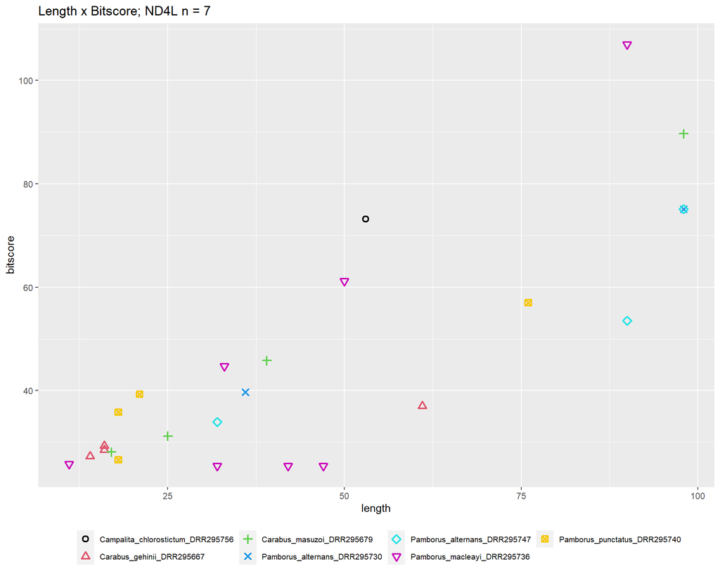

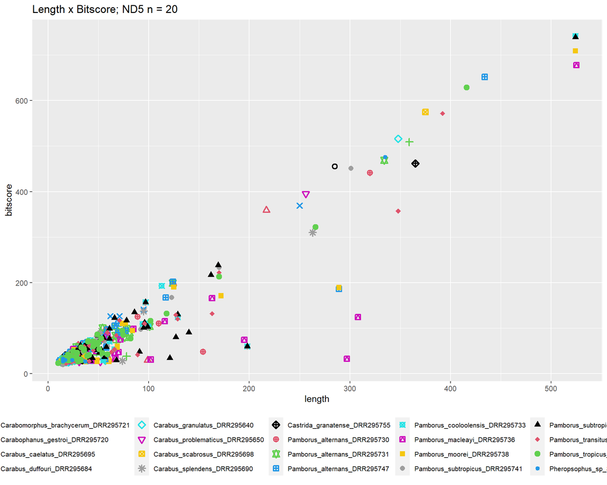

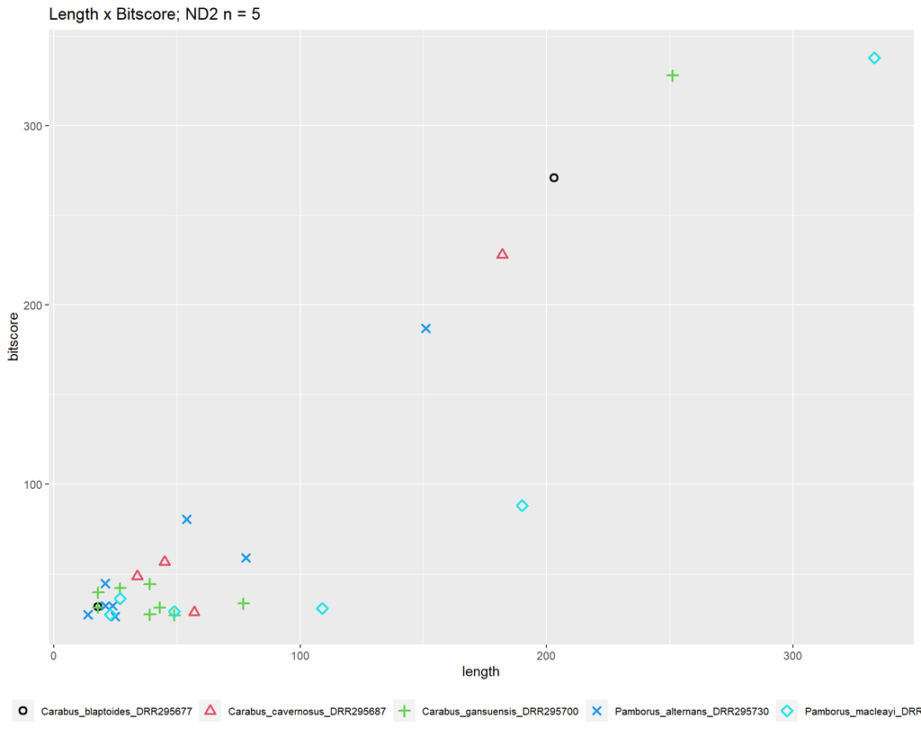

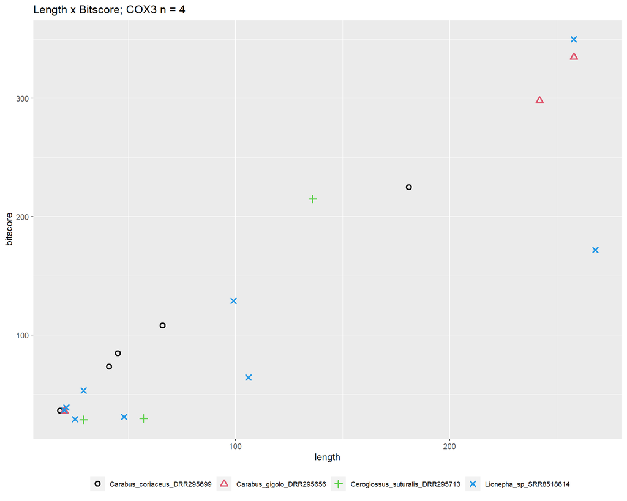

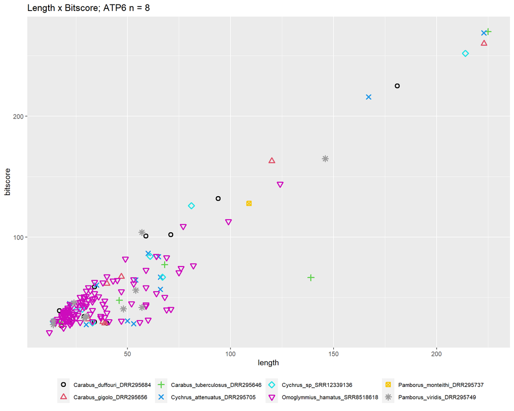

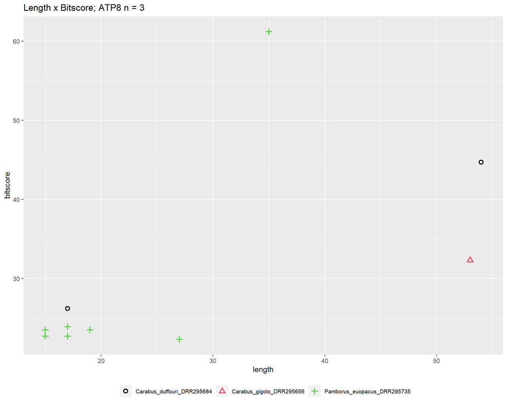

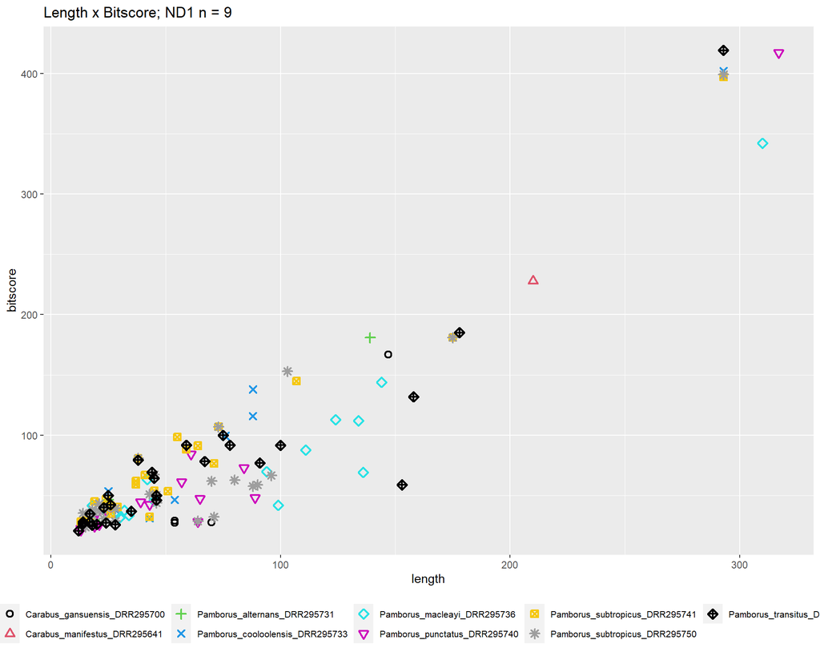

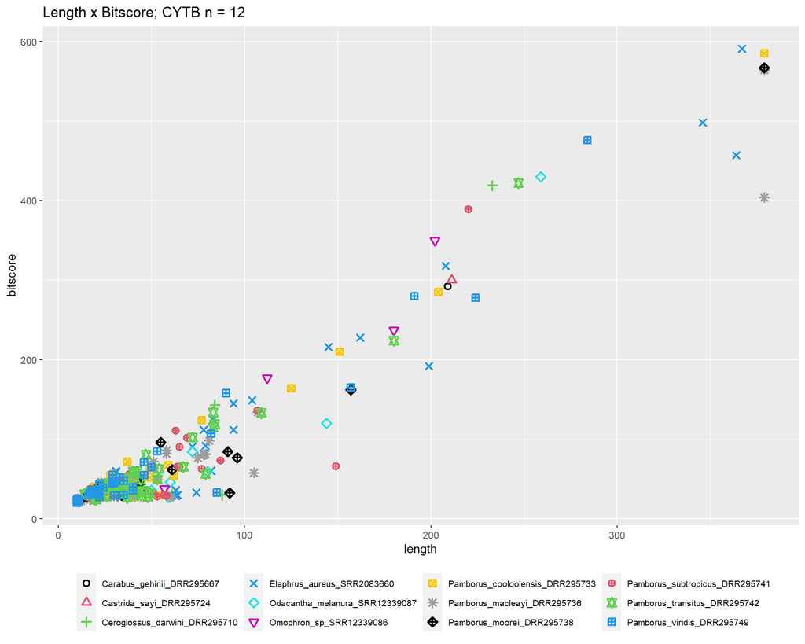

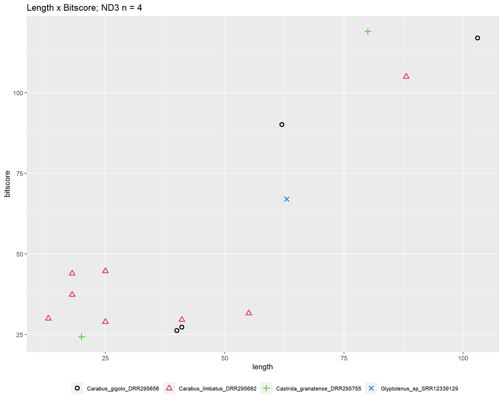

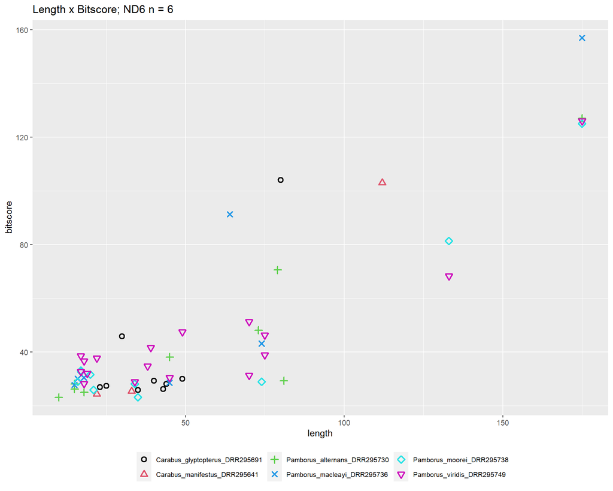

[1 more figures not shown]

```r
genes<-unique(d$gene)

for(i in genes){
  length <- d %>% filter(gene==i) %>% nrow()
  n <- d %>% filter(gene==i) %>% distinct(id) %>% nrow()
  list1 <- d %>% filter(gene==i) %>%
    ggplot(., aes(x= length, y=bitscore)) +
    geom_point(size=2, stroke=1.3,
               aes(shape=id,color=id)) +
    scale_shape_manual(values=1:n) +
    scale_color_manual(values=1:n) +
    theme(legend.title = element_blank(), legend.text=element_text(size=8),
          legend.position="bottom") +
    ggtitle(paste("Length x Bitscore;",i,"n =",n))
  print(list1)
}
```

## Examine a specific sample

We are going to subset and look at a specific taxa’s blast in a similar manner in particular we are going to look at *Calosoma Ctenosta grandidieri* listed as Ctenosta_grandidieriDRR295722 in our balastn results. This is all one gene (ND4) we can examine.

### subset a sample

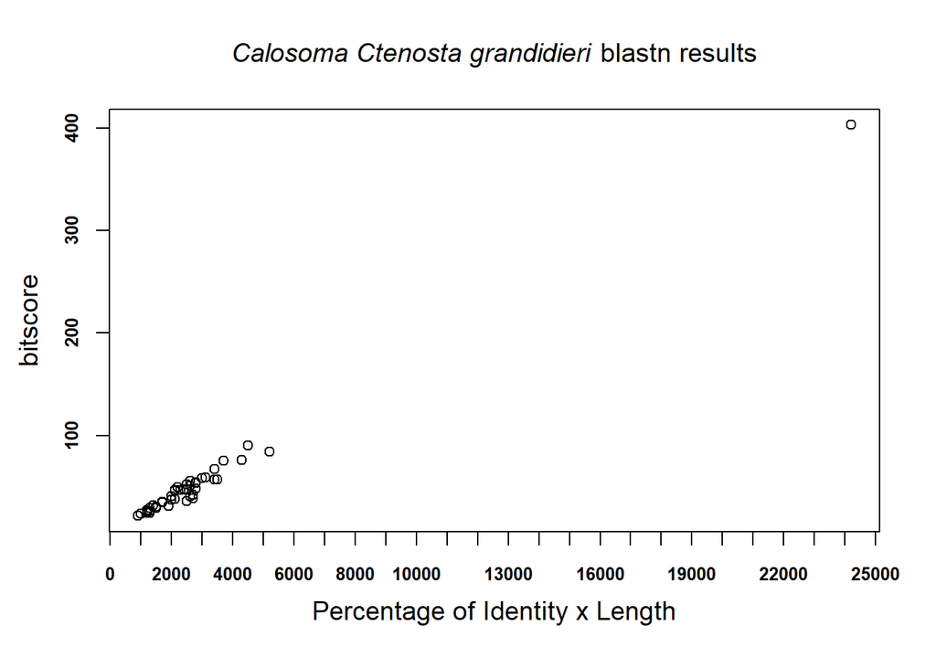

```r
d.CCG <- d %>%  filter(id == "Ctenosta_grandidieri_DRR295722")
plot(x = d.CCG$pident * d.CCG$length, y = d.CCG$bitscore,
     xaxt = "n", yaxt="n", xlab="",ylab="")
  axis(1, xaxp=c(0,25000, 25), las=1, font=2, cex.axis=0.8)
  axis(2, font=2, cex.axis=0.8)
title(main=substitute(paste(italic("Calosoma Ctenosta grandidieri"), " blastn results")),cex.lab=1.2)
title(ylab="bitscore",
      xlab="Percentage of Identity x Length",
      cex.lab=1.2, line =2.5)
```

```r
d.CCG %>% filter(bitscore >= 100)
```

| qseqid | sseqid | pident | length | mismatch | gapopen | qstart | qend | sstart | send | evalue | bitscore | id | gene |
| --- | --- | --- | --- | --- | --- | --- | --- | --- | --- | --- | --- | --- | --- |
| Ctenosta_grandidieri_DRR295722@ND4 | Ctenosta_grandidieri_DRR295722_NODE_34_length_3271_cov_346.801306 | 87.681 | 276 | 34 | 0 | 13 | 288 | 830 | 3 | 3.28e-133 | 403 | Ctenosta_grandidieri_DRR295722 | ND4 |

This is most likely the contig that gave us the mitochondrial gene for ND4; but lets see those others

```r
d.CCG %>% filter(bitscore > 75) %>% select(sseqid,pident,length,gapopen,evalue,bitscore)
```

| sseqid | pident | length | gapopen | evalue | bitscore |
| --- | --- | --- | --- | --- | --- |
| Ctenosta_grandidieri_DRR295722_NODE_87595_length_136_cov_136.024691 | 84.091 | 44 | 0 | 6.64e-18 | 75.5 |
| Ctenosta_grandidieri_DRR295722_NODE_75001_length_214_cov_1.207547 | 66.176 | 68 | 0 | 2.41e-23 | 90.5 |
| Ctenosta_grandidieri_DRR295722_NODE_687_length_806_cov_15.375499 | 61.429 | 70 | 2 | 5.70e-16 | 75.9 |
| Ctenosta_grandidieri_DRR295722_NODE_35320_length_272_cov_0.912442 | 62.651 | 83 | 0 | 1.42e-20 | 84.0 |
| Ctenosta_grandidieri_DRR295722_NODE_34_length_3271_cov_346.801306 | 87.681 | 276 | 0 | 3.28e-133 | 403.0 |

We might select the next contig with the next highest pident, length, evalue, or bit score. But I’m not entirely sure which would be best…. so we *could* examine all of them, but there aught to be a more rigorous way to select these… given I have 69 taxa with at least 1 gene that may take too long.

?? Is there a more automated way to analyize this ??

## Whats up with the ND# genes?

Over half of the genes with issues are ND# genes. Is this an artifact sequencing, assembly, or biologically relevent?

```r
d %>% filter(grepl("ND",gene)) %>% nrow() / d %>%  nrow()
```

```
## [1] 0.5759535
```

We can see that over half of our blast matches are represented by one of the ND# genes…

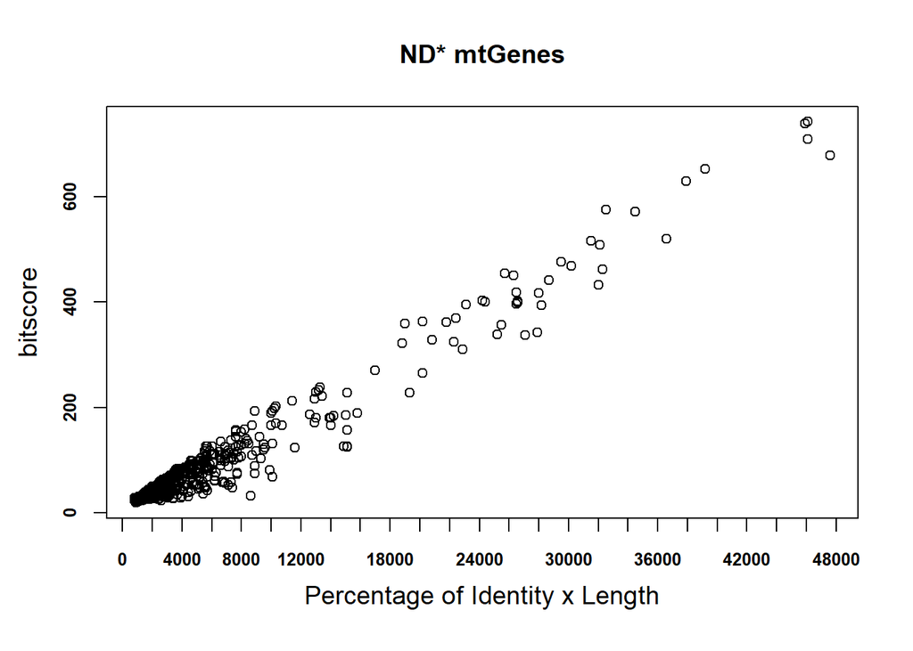

```r
d.ND <- d %>% filter(grepl("ND",gene))
plot(x = d.ND$pident * d.ND$length, y = d.ND$bitscore,
     xaxt = "n", yaxt="n", xlab="",ylab="")
  axis(1, xaxp=c(0,50000, 25), las=1, font=2, cex.axis=0.8)
  axis(2, font=2, cex.axis=0.8)
title(main="ND* mtGenes",cex.lab=1.2)
title(ylab="bitscore",
      xlab="Percentage of Identity x Length",
      cex.lab=1.2, line =2.5)
```

as expected, Same pattern as before, but where do we go from here?

### Summarize statistics…

#### all blastn resulst summary

```r
d %>% select(pident, mismatch, gapopen, evalue, bitscore) %>% summary()
```

```
##      pident          mismatch         gapopen           evalue
##  Min.   : 21.90   Min.   :  0.00   Min.   :0.0000   Min.   : 0.0000
##  1st Qu.: 61.02   1st Qu.:  5.00   1st Qu.:0.0000   1st Qu.: 0.0000
##  Median : 75.00   Median : 10.00   Median :0.0000   Median : 0.0000
##  Mean   : 70.71   Mean   : 16.62   Mean   :0.2889   Mean   : 0.8072
##  3rd Qu.: 83.33   3rd Qu.: 22.00   3rd Qu.:0.0000   3rd Qu.: 0.0550
##  Max.   :100.00   Max.   :186.00   Max.   :7.0000   Max.   :10.0000
##     bitscore
##  Min.   : 19.60
##  1st Qu.: 31.20
##  Median : 43.10
##  Mean   : 79.56
##  3rd Qu.: 74.70
##  Max.   :818.00
```

#### only ND# blasnt results summary

```r
d.ND %>% select(pident, mismatch, gapopen, evalue, bitscore) %>% summary()
```

```
##      pident          mismatch         gapopen           evalue
##  Min.   : 21.90   Min.   :  0.00   Min.   :0.0000   Min.   : 0.000
##  1st Qu.: 61.48   1st Qu.:  5.00   1st Qu.:0.0000   1st Qu.: 0.000
##  Median : 75.00   Median : 10.00   Median :0.0000   Median : 0.000
##  Mean   : 70.89   Mean   : 16.37   Mean   :0.2873   Mean   : 0.755
##  3rd Qu.: 83.33   3rd Qu.: 21.00   3rd Qu.:0.0000   3rd Qu.: 0.043
##  Max.   :100.00   Max.   :186.00   Max.   :7.0000   Max.   :10.000
##     bitscore
##  Min.   : 19.6
##  1st Qu.: 31.2
##  Median : 42.4
##  Mean   : 73.0
##  3rd Qu.: 69.3
##  Max.   :742.0
```

#### excluding all ND# from summary

```r
d %>% filter(!grepl("ND",gene)) %>% select(pident, mismatch, gapopen, evalue, bitscore) %>% summary()
```

```
##      pident          mismatch         gapopen           evalue
##  Min.   : 22.95   Min.   :  0.00   Min.   :0.0000   Min.   :0.0000
##  1st Qu.: 60.00   1st Qu.:  5.00   1st Qu.:0.0000   1st Qu.:0.0000
##  Median : 75.00   Median : 11.00   Median :0.0000   Median :0.0000
##  Mean   : 70.48   Mean   : 16.97   Mean   :0.2912   Mean   :0.8781
##  3rd Qu.: 83.78   3rd Qu.: 23.00   3rd Qu.:0.0000   3rd Qu.:0.0940
##  Max.   :100.00   Max.   :175.00   Max.   :4.0000   Max.   :9.9000
##     bitscore
##  Min.   : 20.40
##  1st Qu.: 31.20
##  Median : 43.30
##  Mean   : 88.46
##  3rd Qu.: 84.30
##  Max.   :818.00
```

Is it reasonable to create a new column that gives us a ratio = (pidnt*length) / bitscore and exclude anything outside of a lower 95% confidence interval?

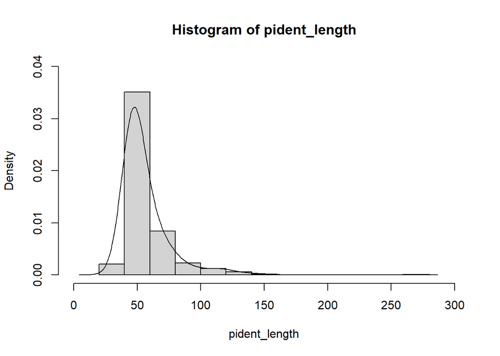

```r
pident_length <- (d.ND$pident*d.ND$length)/d.ND$bitscore
hist(pident_length, prob=T,  ylim=c(0,0.04),xlim=c(0,300))
lines(density(pident_length, adjust=3))
```

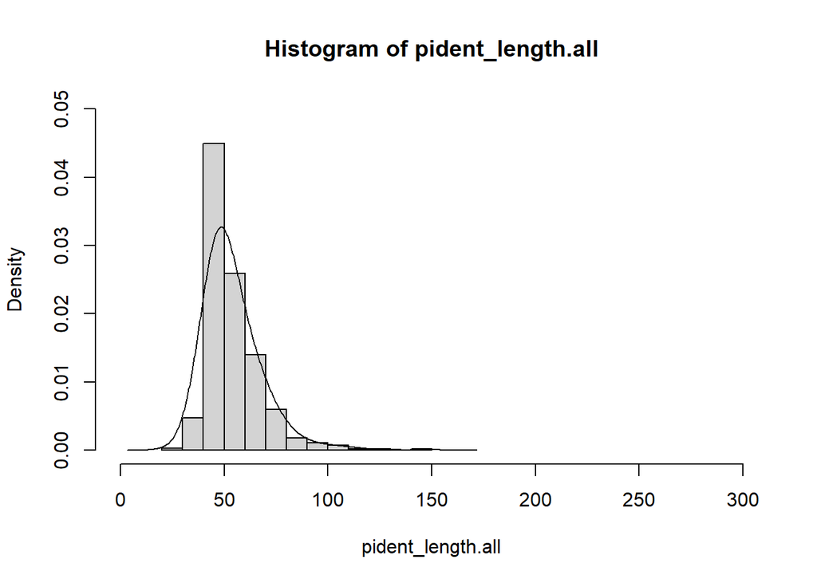

```r
all <- d %>% filter(!grepl("ND",gene)) %>% select(pident, length, bitscore)
pident_length.all <- (all$pident*all$length)/all$bitscore
hist(pident_length.all, prob=T,  ylim=c(0,0.05), xlim=c(0,300))
lines(density(pident_length.all, adjust=3))
```

ND% genes dont seem to behave too differently from other samples, this may kick some samples, but that is OK for now maybe. This is probably the biggest issue with the mitochondrial analyses. I already have identified 1-2 samples that will have to be removed anyways.

Adding the ratio that’s been calculated using dplyr::mutate

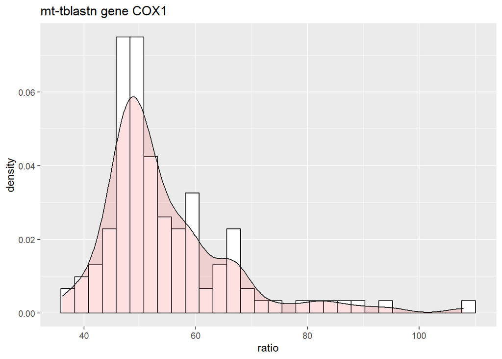

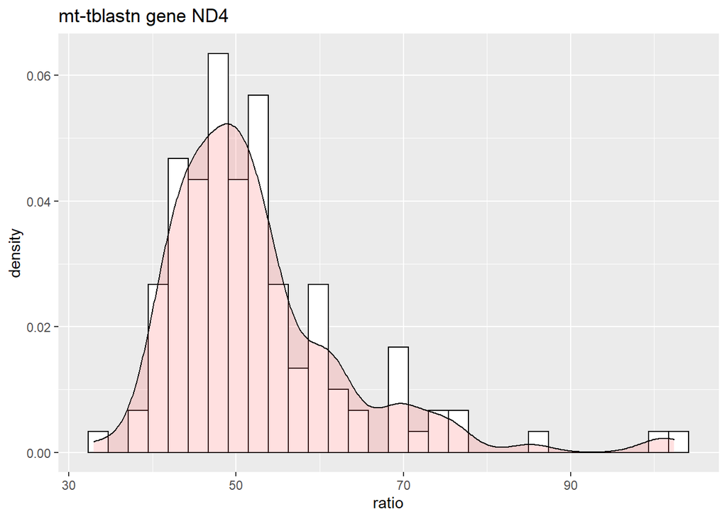

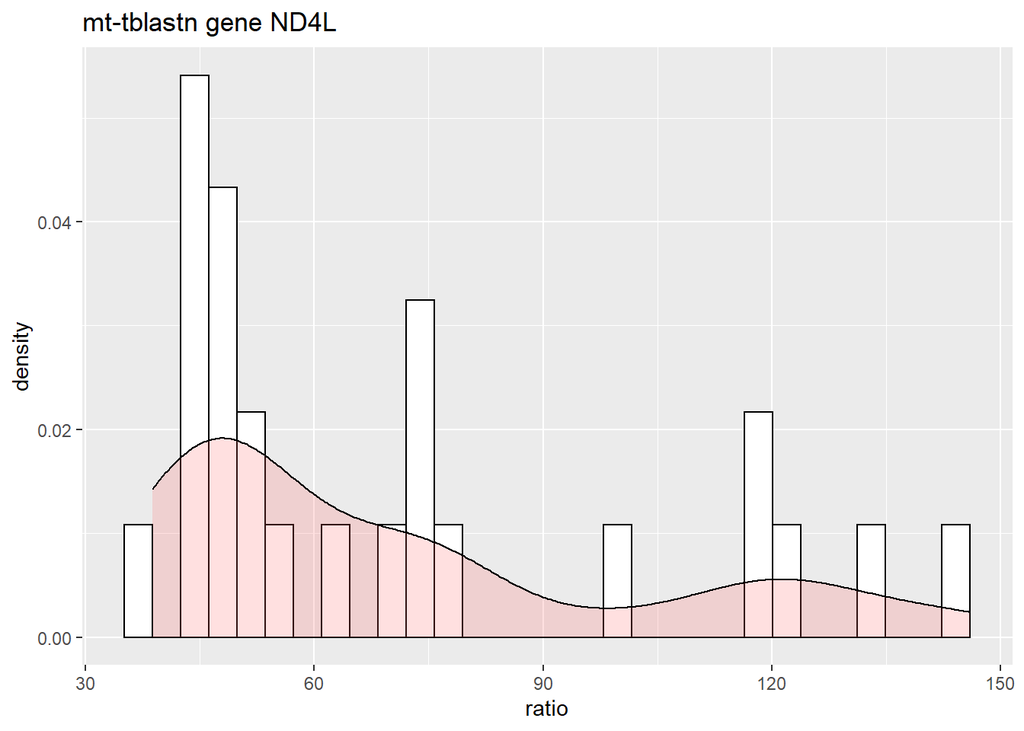

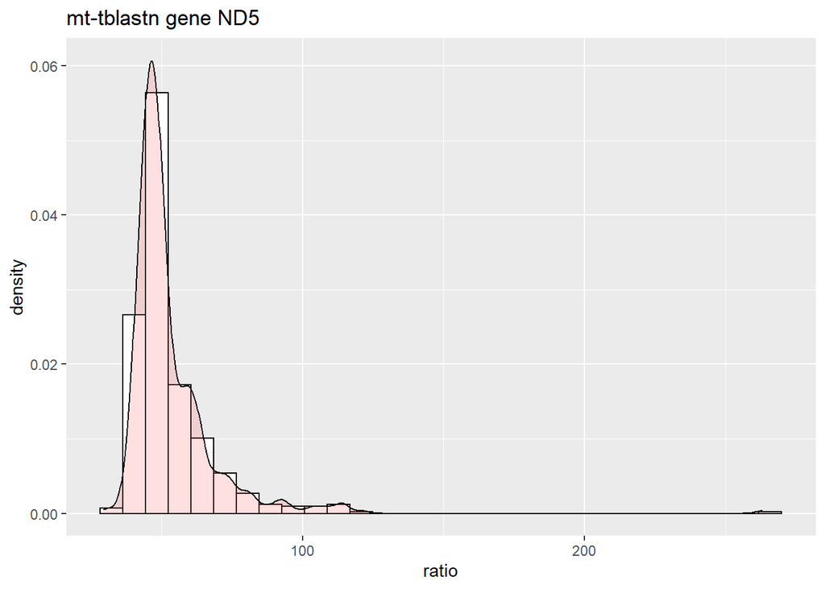

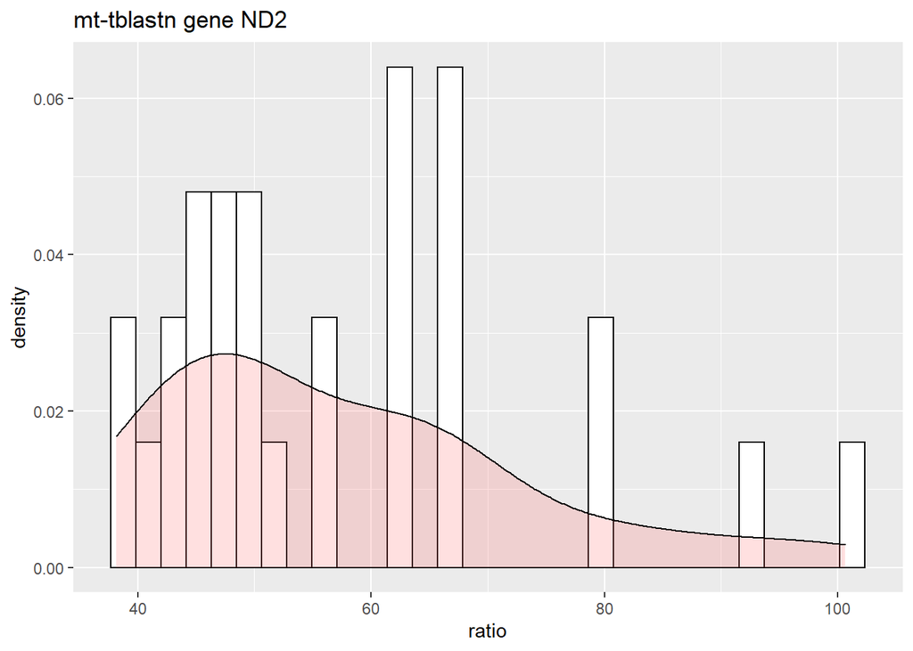

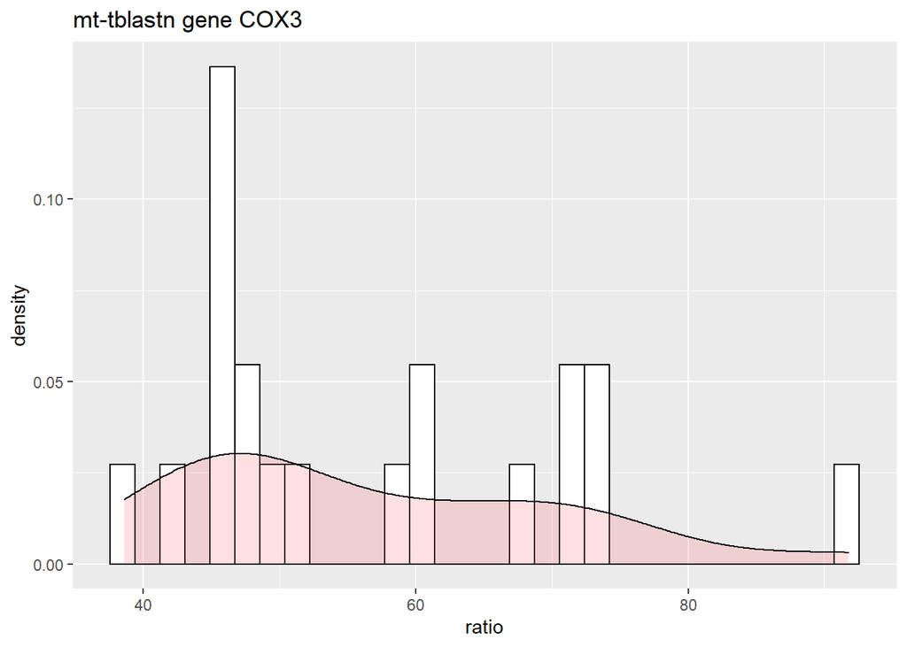

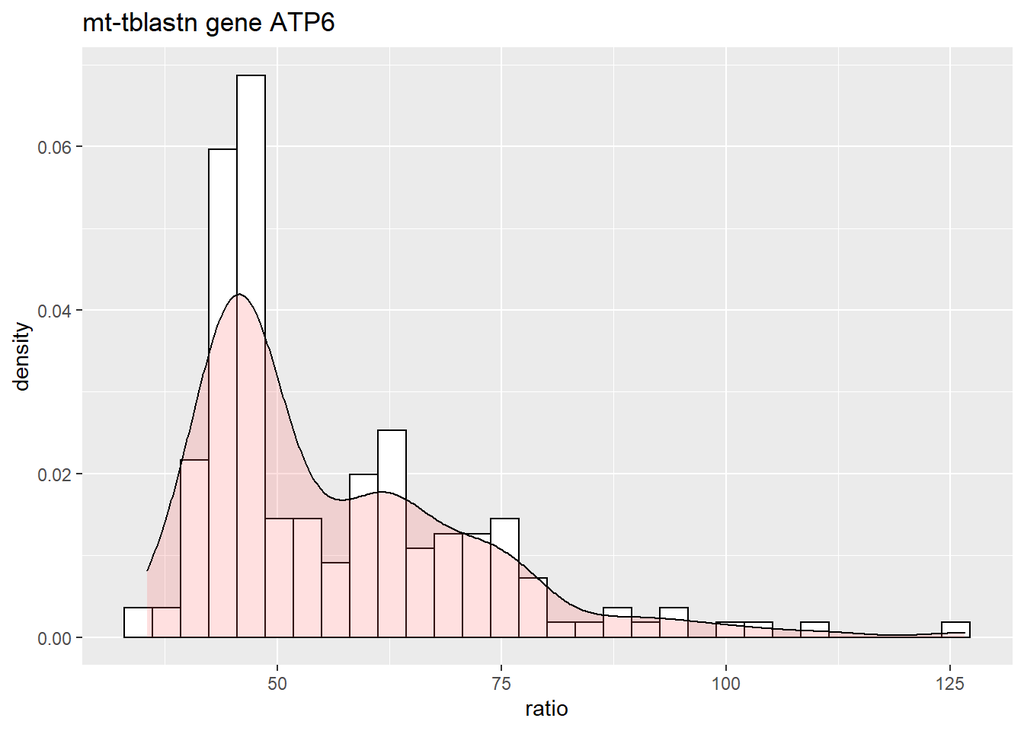

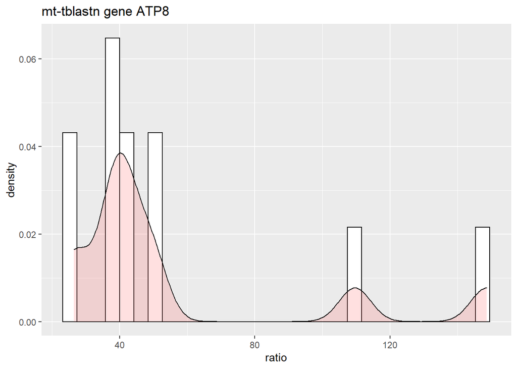

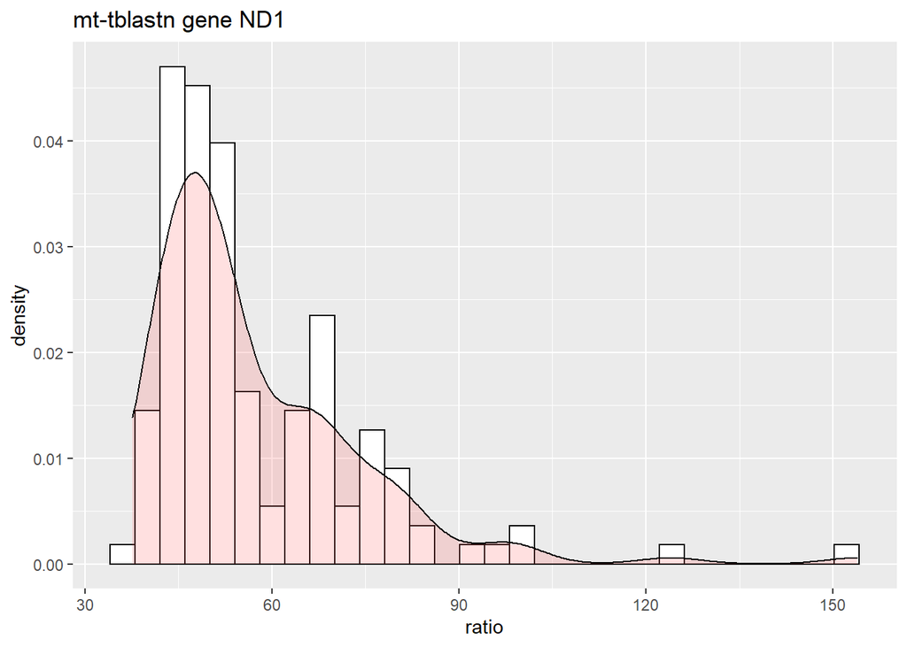

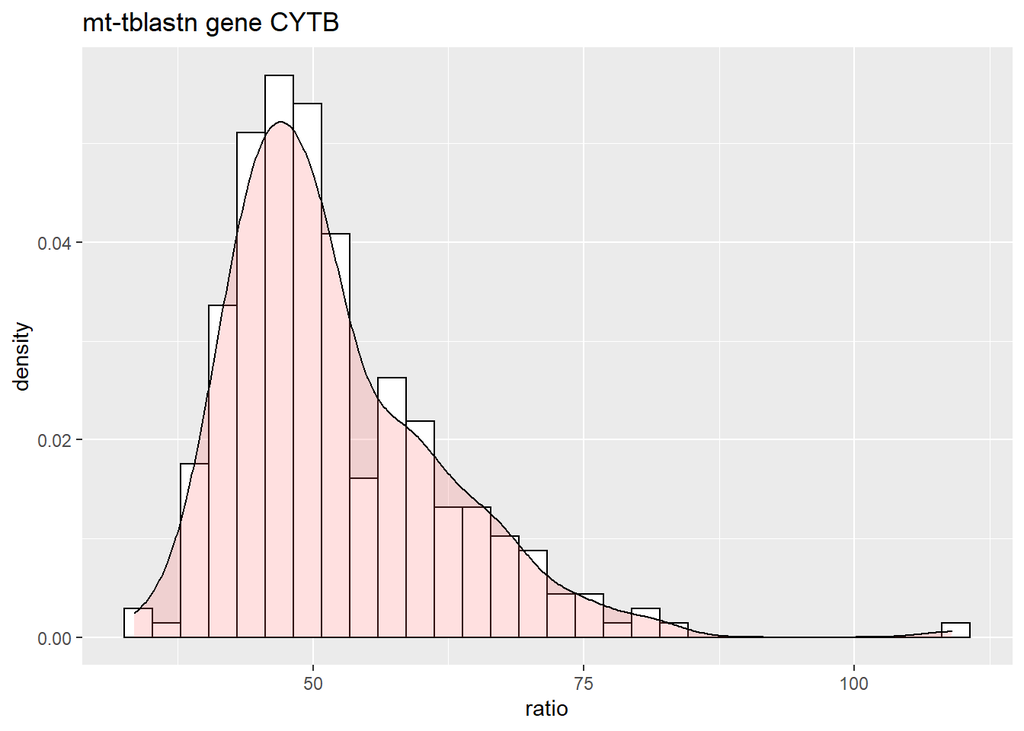

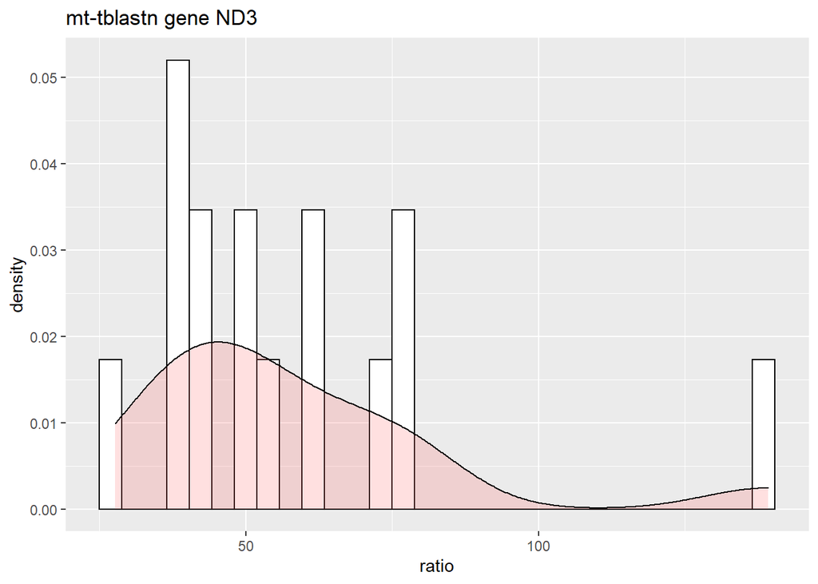

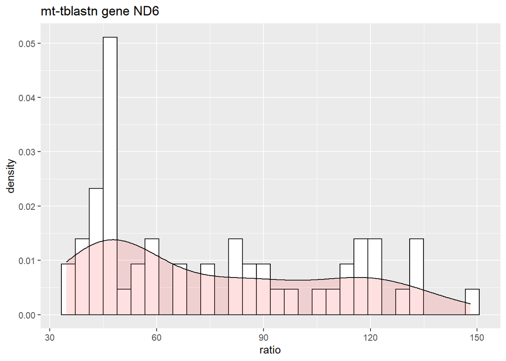

[1 more figures not shown]

```r
d2 <- d %>% mutate(ratio = (pident*length)/bitscore)

for(i in genes){
  list2 <- d2 %>% filter (gene==i) %>%
    ggplot(., aes(x = ratio)) +
    geom_histogram(aes(y=..density..), colour="black", fill="white") +
    geom_density(alpha=.2, fill="#FF6666") +
    ggtitle(paste("mt-tblastn gene",i))
  print(list2)
}
```